# welcome

#### Filter, Select, and Mutate Functions

Filter (selects rows that meet some criteria)

```r
diamonds %>% filter(price < 1000)
```

```
# A tibble: 14,499 × 10
   carat cut       color clarity depth table price     x     y     z
   <dbl> <ord>     <ord> <ord>   <dbl> <dbl> <int> <dbl> <dbl> <dbl>
 1  0.23 Ideal     E     SI2      61.5    55   326  3.95  3.98  2.43
 2  0.21 Premium   E     SI1      59.8    61   326  3.89  3.84  2.31
 3  0.23 Good      E     VS1      56.9    65   327  4.05  4.07  2.31
 4  0.29 Premium   I     VS2      62.4    58   334  4.2   4.23  2.63
 5  0.31 Good      J     SI2      63.3    58   335  4.34  4.35  2.75
 6  0.24 Very Good J     VVS2     62.8    57   336  3.94  3.96  2.48
 7  0.24 Very Good I     VVS1     62.3    57   336  3.95  3.98  2.47
 8  0.26 Very Good H     SI1      61.9    55   337  4.07  4.11  2.53
 9  0.22 Fair      E     VS2      65.1    61   337  3.87  3.78  2.49
10  0.23 Very Good H     VS1      59.4    61   338  4     4.05  2.39
# … with 14,489 more rows
```

```r
#notice how this code is different
#what is the difference?
cheap = diamonds %>% filter(price < 1000)

summary(cheap)
```

```
     carat               cut       color       clarity         depth
 Min.   :0.2000   Fair     : 111   D:2030   VS2    :3611   Min.   :51.00
 1st Qu.:0.3000   Good     :1110   E:3038   SI1    :3084   1st Qu.:61.20
 Median :0.3200   Very Good:3240   F:2470   VS1    :2459   Median :61.80
 Mean   :0.3348   Premium  :3200   G:3170   VVS2   :1919   Mean   :61.75
 3rd Qu.:0.3700   Ideal    :6838   H:2101   VVS1   :1541   3rd Qu.:62.40
 Max.   :0.7200                    I:1228   SI2    :1071   Max.   :71.00
                                   J: 462   (Other): 814
     table           price             x              y               z
 Min.   :44.00   Min.   :326.0   Min.   :3.73   Min.   :3.680   Min.   :2.240
 1st Qu.:55.00   1st Qu.:579.0   1st Qu.:4.31   1st Qu.:4.320   1st Qu.:2.670
 Median :57.00   Median :708.0   Median :4.41   Median :4.420   Median :2.720
 Mean   :56.97   Mean   :707.9   Mean   :4.45   Mean   :4.462   Mean   :2.752
 3rd Qu.:58.00   3rd Qu.:840.0   3rd Qu.:4.61   3rd Qu.:4.620   3rd Qu.:2.840
 Max.   :68.00   Max.   :999.0   Max.   :6.65   Max.   :6.020   Max.   :4.440
```

```r
str(cheap)
```

```
tibble [14,499 × 10] (S3: tbl_df/tbl/data.frame)
 $ carat  : num [1:14499] 0.23 0.21 0.23 0.29 0.31 0.24 0.24 0.26 0.22 0.23 ...
 $ cut    : Ord.factor w/ 5 levels "Fair"<"Good"<..: 5 4 2 4 2 3 3 3 1 3 ...
 $ color  : Ord.factor w/ 7 levels "D"<"E"<"F"<"G"<..: 2 2 2 6 7 7 6 5 2 5 ...
 $ clarity: Ord.factor w/ 8 levels "I1"<"SI2"<"SI1"<..: 2 3 5 4 2 6 7 3 4 5 ...
 $ depth  : num [1:14499] 61.5 59.8 56.9 62.4 63.3 62.8 62.3 61.9 65.1 59.4 ...
 $ table  : num [1:14499] 55 61 65 58 58 57 57 55 61 61 ...
 $ price  : int [1:14499] 326 326 327 334 335 336 336 337 337 338 ...
 $ x      : num [1:14499] 3.95 3.89 4.05 4.2 4.34 3.94 3.95 4.07 3.87 4 ...
 $ y      : num [1:14499] 3.98 3.84 4.07 4.23 4.35 3.96 3.98 4.11 3.78 4.05 ...
 $ z      : num [1:14499] 2.43 2.31 2.31 2.63 2.75 2.48 2.47 2.53 2.49 2.39 ...
```

Select (selects columns, typically by name)

```r
prices = diamonds %>% select(price)
str(prices)
```

```
tibble [53,940 × 1] (S3: tbl_df/tbl/data.frame)
 $ price: int [1:53940] 326 326 327 334 335 336 336 337 337 338 ...
```

```r
nd = diamonds %>% select(-depth) #all columns but depth
str(nd)
```

```
tibble [53,940 × 9] (S3: tbl_df/tbl/data.frame)
 $ carat  : num [1:53940] 0.23 0.21 0.23 0.29 0.31 0.24 0.24 0.26 0.22 0.23 ...
 $ cut    : Ord.factor w/ 5 levels "Fair"<"Good"<..: 5 4 2 4 2 3 3 3 1 3 ...
 $ color  : Ord.factor w/ 7 levels "D"<"E"<"F"<"G"<..: 2 2 2 6 7 7 6 5 2 5 ...
 $ clarity: Ord.factor w/ 8 levels "I1"<"SI2"<"SI1"<..: 2 3 5 4 2 6 7 3 4 5 ...
 $ table  : num [1:53940] 55 61 65 58 58 57 57 55 61 61 ...
 $ price  : int [1:53940] 326 326 327 334 335 336 336 337 337 338 ...
 $ x      : num [1:53940] 3.95 3.89 4.05 4.2 4.34 3.94 3.95 4.07 3.87 4 ...
 $ y      : num [1:53940] 3.98 3.84 4.07 4.23 4.35 3.96 3.98 4.11 3.78 4.05 ...
 $ z      : num [1:53940] 2.43 2.31 2.31 2.63 2.75 2.48 2.47 2.53 2.49 2.39 ...
```

```r
diamonds2 = diamonds %>% select(c(price,carat,cut,color))
str(diamonds2)
```

```
tibble [53,940 × 4] (S3: tbl_df/tbl/data.frame)
 $ price: int [1:53940] 326 326 327 334 335 336 336 337 337 338 ...
 $ carat: num [1:53940] 0.23 0.21 0.23 0.29 0.31 0.24 0.24 0.26 0.22 0.23 ...
 $ cut  : Ord.factor w/ 5 levels "Fair"<"Good"<..: 5 4 2 4 2 3 3 3 1 3 ...
 $ color: Ord.factor w/ 7 levels "D"<"E"<"F"<"G"<..: 2 2 2 6 7 7 6 5 2 5 ...
```

Mutate (creates new columns or modifies existing ones)

```r
diamonds = diamonds %>% mutate(pricepercarat = price/carat)
str(diamonds)
```

```
tibble [53,940 × 11] (S3: tbl_df/tbl/data.frame)
 $ carat        : num [1:53940] 0.23 0.21 0.23 0.29 0.31 0.24 0.24 0.26 0.22 0.23 ...
 $ cut          : Ord.factor w/ 5 levels "Fair"<"Good"<..: 5 4 2 4 2 3 3 3 1 3 ...
 $ color        : Ord.factor w/ 7 levels "D"<"E"<"F"<"G"<..: 2 2 2 6 7 7 6 5 2 5 ...
 $ clarity      : Ord.factor w/ 8 levels "I1"<"SI2"<"SI1"<..: 2 3 5 4 2 6 7 3 4 5 ...
 $ depth        : num [1:53940] 61.5 59.8 56.9 62.4 63.3 62.8 62.3 61.9 65.1 59.4 ...
 $ table        : num [1:53940] 55 61 65 58 58 57 57 55 61 61 ...
 $ price        : int [1:53940] 326 326 327 334 335 336 336 337 337 338 ...
 $ x            : num [1:53940] 3.95 3.89 4.05 4.2 4.34 3.94 3.95 4.07 3.87 4 ...
 $ y            : num [1:53940] 3.98 3.84 4.07 4.23 4.35 3.96 3.98 4.11 3.78 4.05 ...
 $ z            : num [1:53940] 2.43 2.31 2.31 2.63 2.75 2.48 2.47 2.53 2.49 2.39 ...
 $ pricepercarat: num [1:53940] 1417 1552 1422 1152 1081 ...
```

Return to PowerPoint for visualization/ggplot2 lectures.

#### Plotting and Chart Types

Scatterplots are used to view the relationship between two quantitative variables.

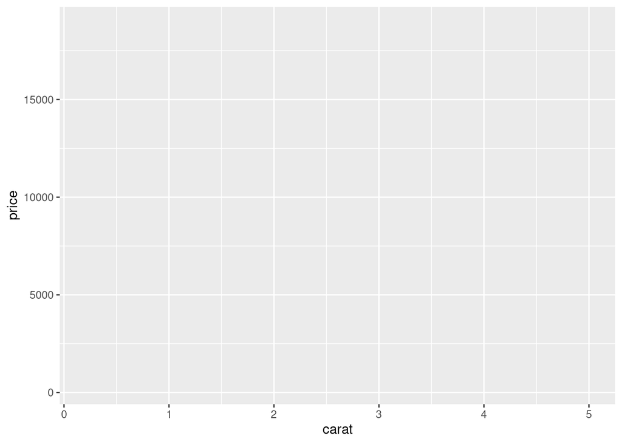

```r
#pay attention to the pattern of this function
ggplot(diamonds, aes(x = carat, y = price))
```

```r
#what does this function do?
```

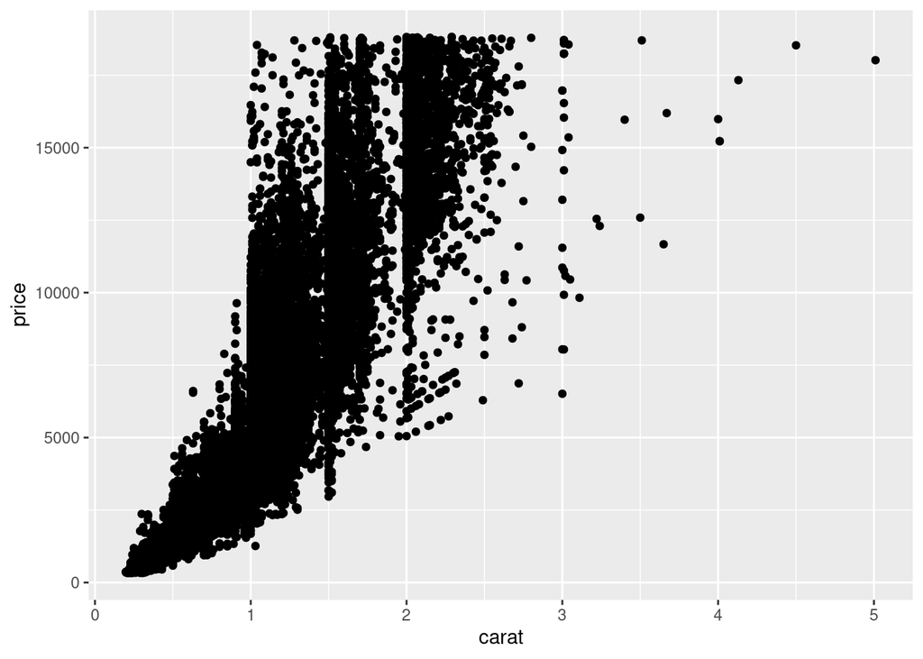

```r
ggplot(diamonds, aes(x = carat, y = price)) + geom_point()
```

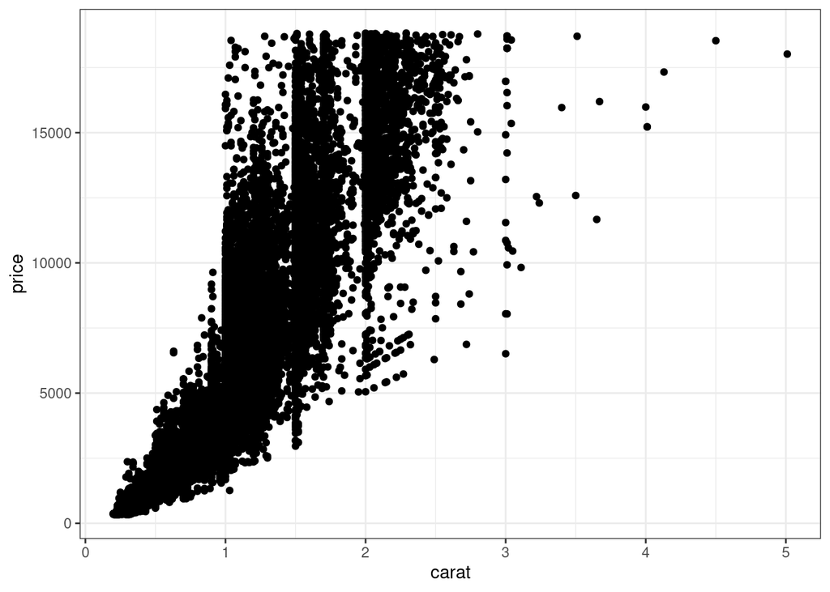

```r
ggplot(diamonds, aes(x = carat, y = price)) + geom_point() + theme_bw()
```

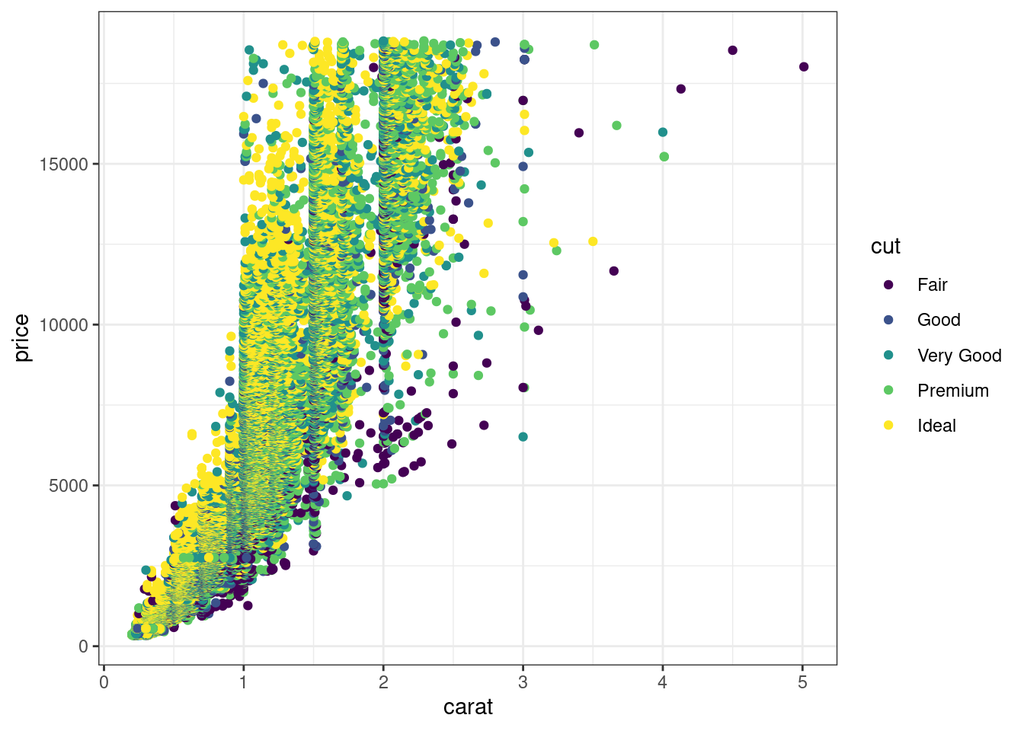

```r
ggplot(diamonds, aes(x = carat, y = price, color = cut)) + geom_point() + theme_bw()
```

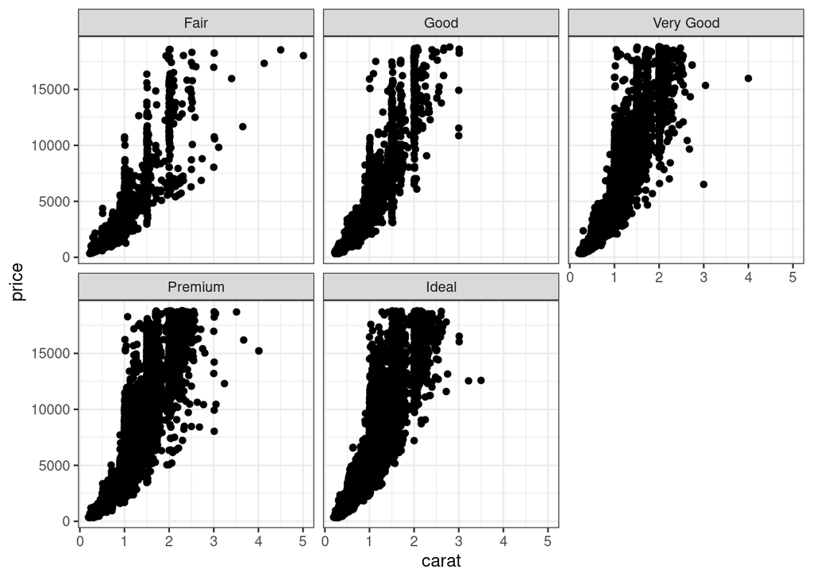

```r
ggplot(diamonds, aes(x = carat, y = price)) + geom_point() + facet_wrap(~cut) + theme_bw()
```

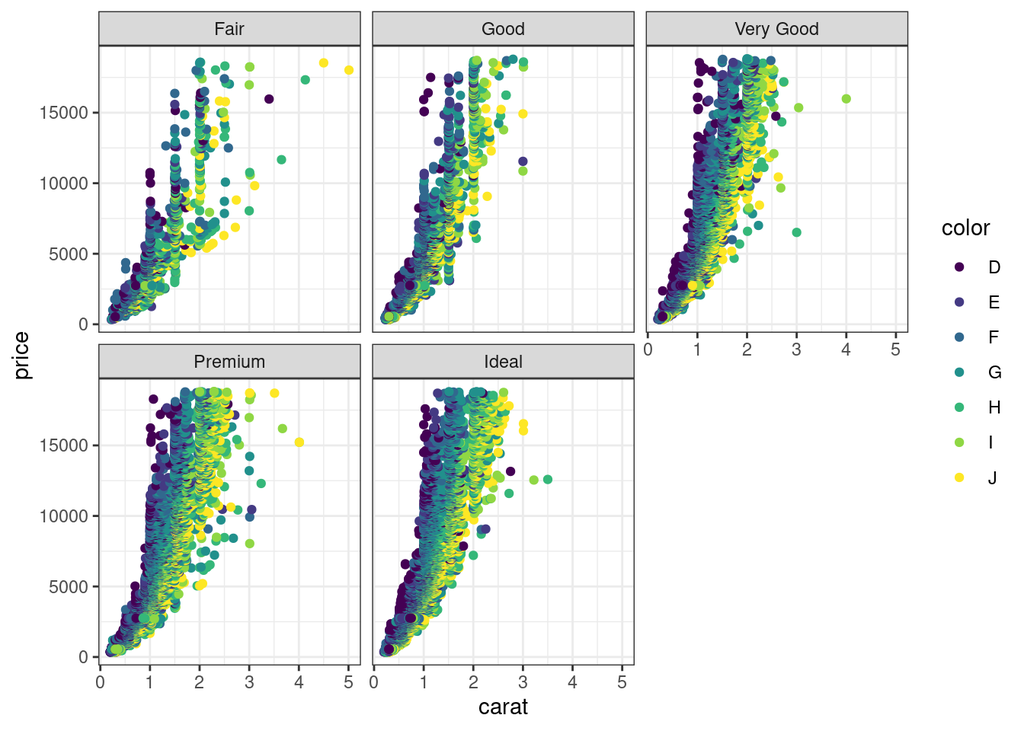

```r
ggplot(diamonds, aes(x = carat, y = price, color = color)) + geom_point() + facet_wrap(~cut) + theme_bw()
```

Histograms are used to examine the distribution of a single quantitative variable.

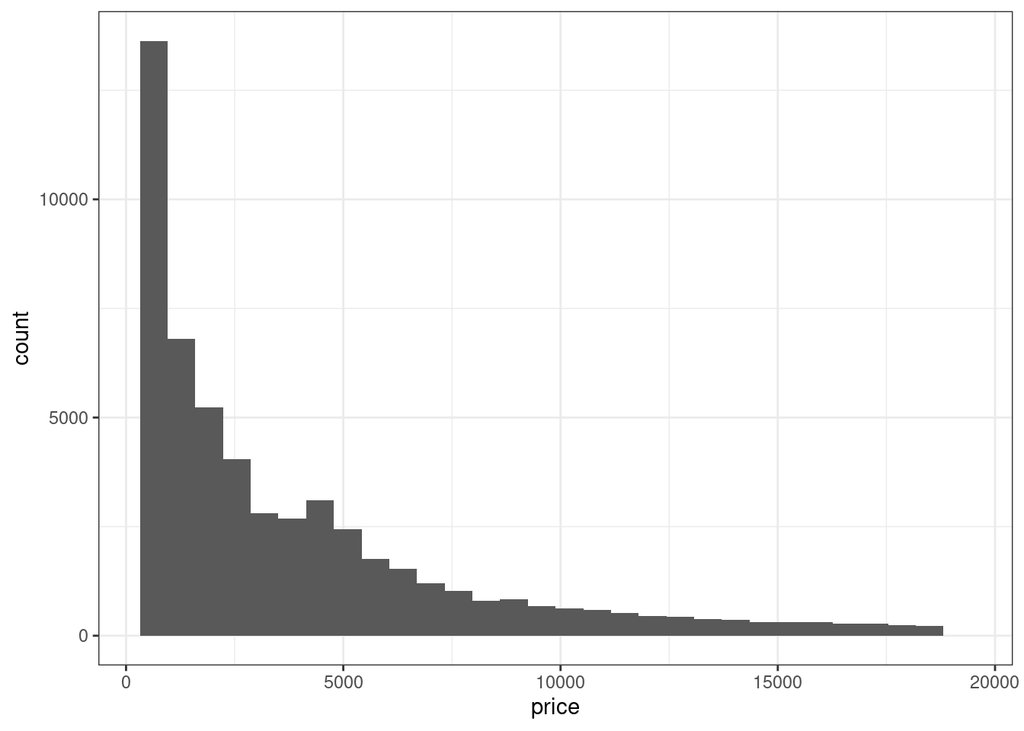

```r
ggplot(diamonds,aes(x=price)) + geom_histogram() + theme_bw()
```

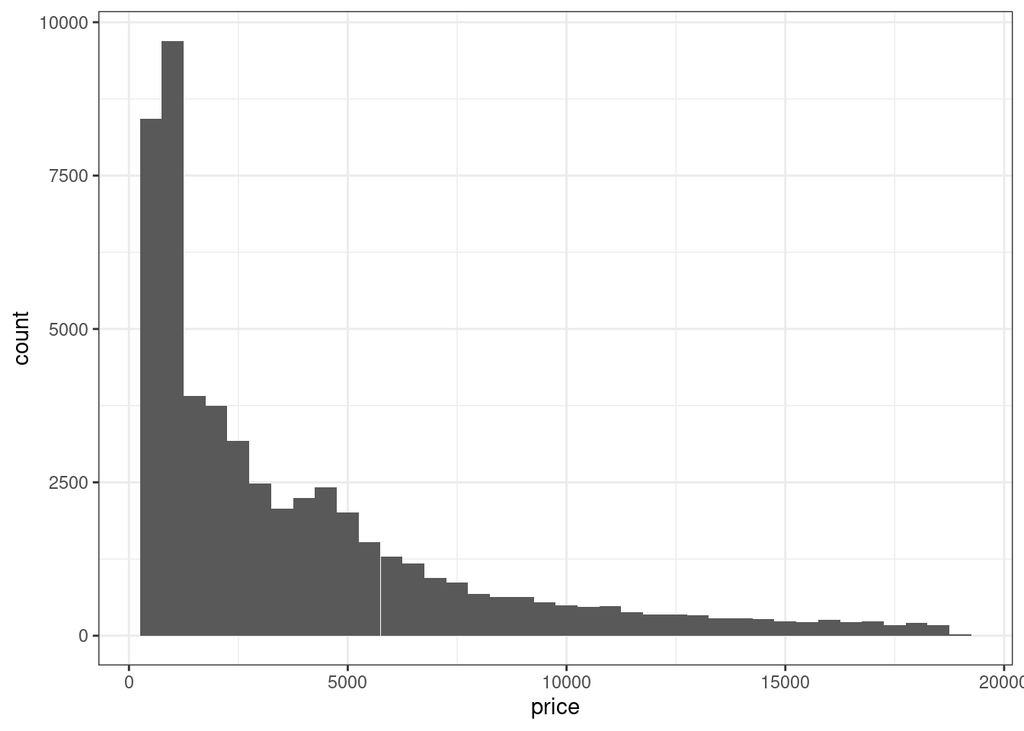

```r
ggplot(diamonds,aes(x=price)) + geom_histogram(binwidth = 500) + theme_bw()
```

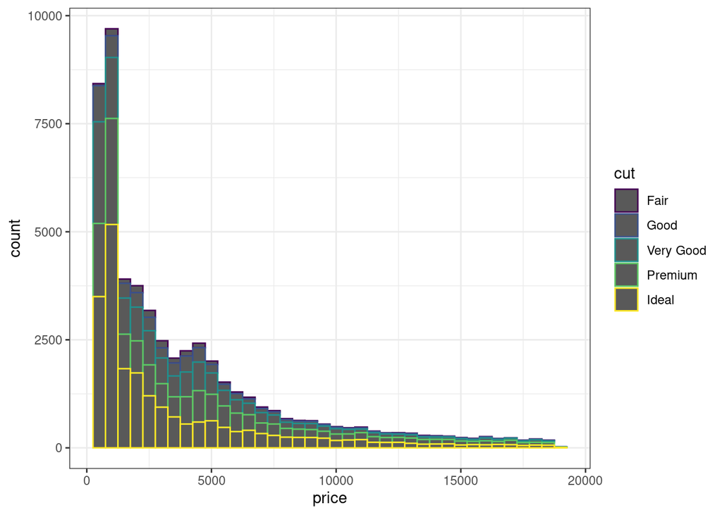

```r
ggplot(diamonds,aes(x=price, color = cut)) + geom_histogram(binwidth = 500) + theme_bw()
```

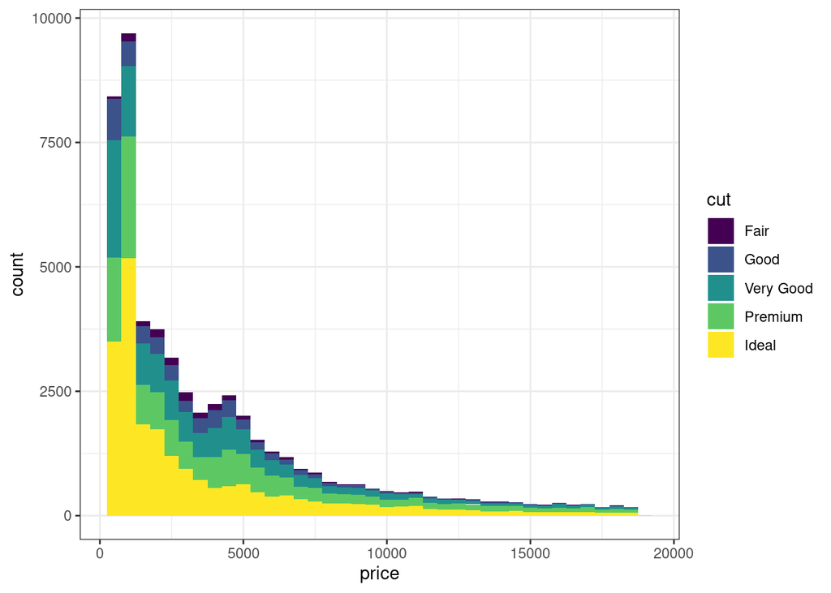

```r
ggplot(diamonds,aes(x=price, fill = cut)) + geom_histogram(binwidth = 500) + theme_bw()
```

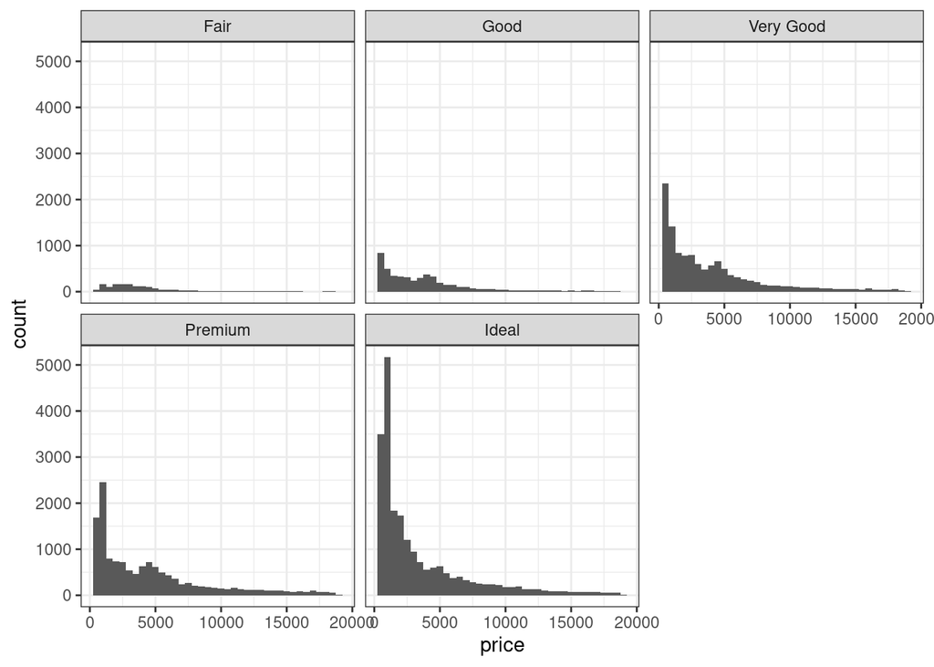

```r
ggplot(diamonds,aes(x=price)) + geom_histogram(binwidth = 500) + facet_wrap(~cut) + theme_bw()
```

Barplots are primarily used to show counts of data in categories. More challenging if you want to use barplot to display something this is NOT a count. We’ll cover later.

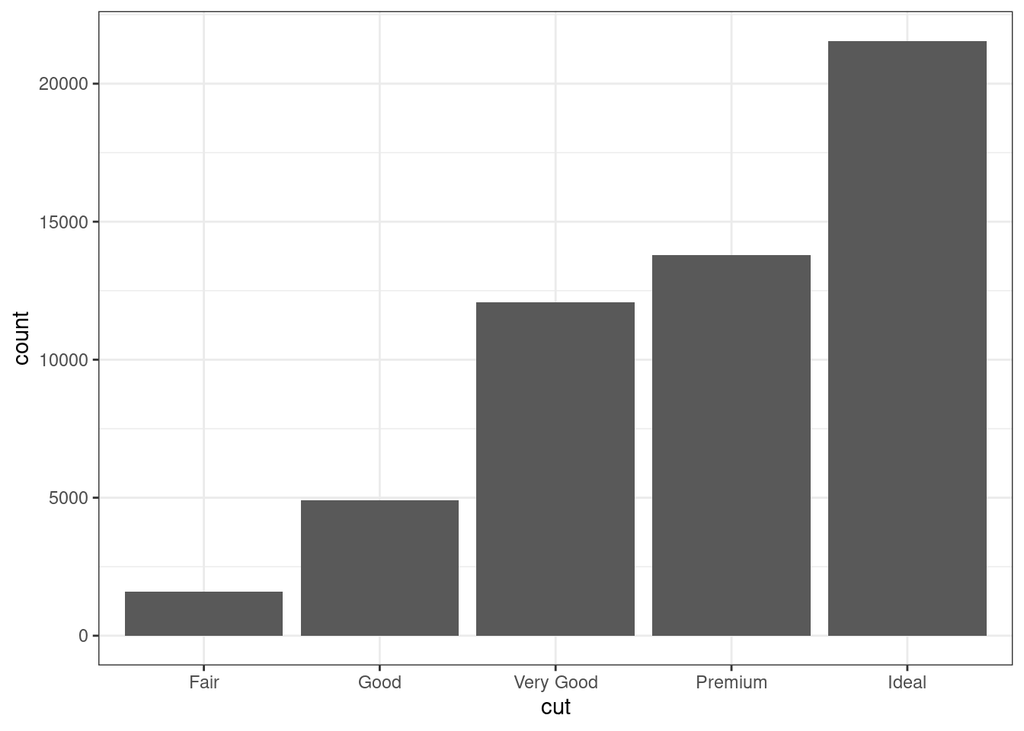

```r
ggplot(diamonds, aes(x=cut)) + geom_bar() + theme_bw()
```

Boxplots are used to show the distribution of a quantitative variable across categories. In some situations, other plot types may be more appropriate.

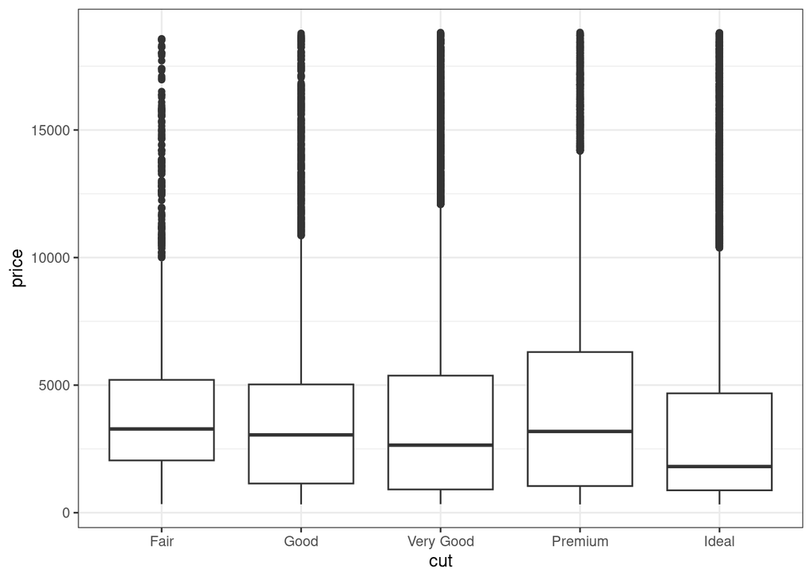

```r
ggplot(diamonds, aes(x=cut, y=price)) + geom_boxplot() + theme_bw()
```

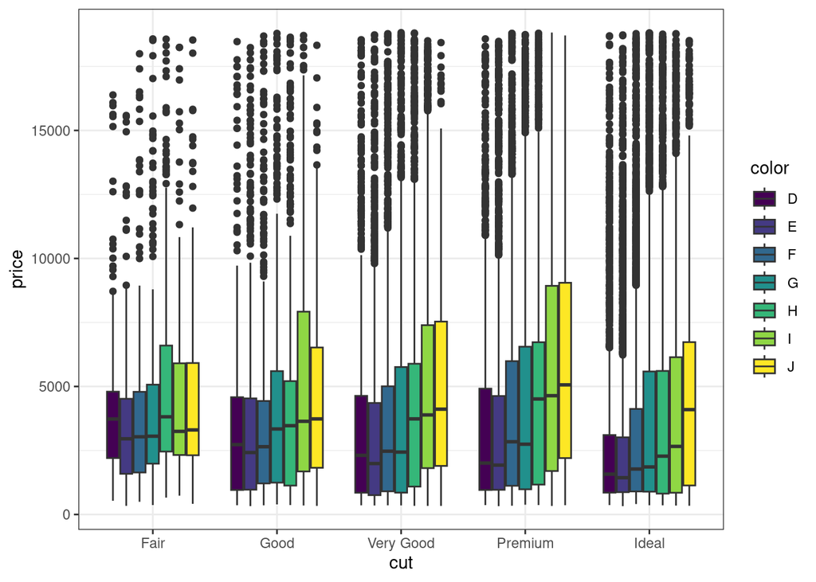

```r
ggplot(diamonds, aes(x=cut, y=price, fill = color)) + geom_boxplot() + theme_bw()
```